# [S&P 500 Stocks](https://www.kaggle.com/datasets/andrewmvd/sp-500-stocks)

This Dataset illustrates the detailed insinghts on the index of the TOP 500 Stocks on the Stock Market. The data that will be used in this research is publicly available for everyone.

The main idea of the project:

```
- Make analys on the Dataset
- Check the Hypothesis
```

```python
import pandas as pd
import numpy as np
import seaborn as sns
import matplotlib.pyplot as plt
```

# Overall stats

Down below we can see the whole dataset with all its columns and field values. If you look closely, you can notice that the DATA has already been sorted by `MARKETCAP` value. So the first one is Apple, then Nvidia and so on.

```python
data = pd.read_csv('data/sp500_companies.csv')
data
```

|  | Exchange | Symbol | Shortname | Longname | Sector | Industry | Currentprice | Marketcap | Ebitda | Revenuegrowth | City | State | Country | Fulltimeemployees | Longbusinesssummary | Weight |
| --- | --- | --- | --- | --- | --- | --- | --- | --- | --- | --- | --- | --- | --- | --- | --- | --- |
| 0 | NMS | AAPL | Apple Inc. | Apple Inc. | Technology | Consumer Electronics | 242.84 | 3670720643072 | 1.346610e+11 | 0.061 | Cupertino | CA | United States | 164000.0 | Apple Inc. designs, manufactures, and markets ... | 0.064589 |
| 1 | NMS | NVDA | NVIDIA Corporation | NVIDIA Corporation | Technology | Semiconductors | 142.44 | 3488355713024 | 6.118400e+10 | 1.224 | Santa Clara | CA | United States | 29600.0 | NVIDIA Corporation provides graphics and compu... | 0.061381 |
| 2 | NMS | MSFT | Microsoft Corporation | Microsoft Corporation | Technology | Software - Infrastructure | 443.57 | 3297889746944 | 1.365520e+11 | 0.160 | Redmond | WA | United States | 228000.0 | Microsoft Corporation develops and supports so... | 0.058029 |
| 3 | NMS | AMZN | Amazon.com, Inc. | Amazon.com, Inc. | Consumer Cyclical | Internet Retail | 227.03 | 2387220627456 | 1.115830e+11 | 0.110 | Seattle | WA | United States | 1551000.0 | Amazon.com, Inc. engages in the retail sale of... | 0.042005 |
| 4 | NMS | GOOG | Alphabet Inc. | Alphabet Inc. | Communication Services | Internet Content & Information | 176.49 | 2149065949184 | 1.234700e+11 | 0.151 | Mountain View | CA | United States | 181269.0 | Alphabet Inc. offers various products and plat... | 0.037815 |
| ... | ... | ... | ... | ... | ... | ... | ... | ... | ... | ... | ... | ... | ... | ... | ... | ... |
| 498 | NYQ | BWA | BorgWarner Inc. | BorgWarner Inc. | Consumer Cyclical | Auto Parts | 33.80 | 7392059904 | 1.882000e+09 | -0.048 | Auburn Hills | MI | United States | 39900.0 | BorgWarner Inc., together with its subsidiarie... | 0.000130 |
| 499 | NYQ | HII | Huntington Ingalls Industries, | Huntington Ingalls Industries, Inc. | Industrials | Aerospace & Defense | 187.95 | 7354351616 | 1.071000e+09 | -0.024 | Newport News | VA | United States | 44000.0 | Huntington Ingalls Industries, Inc. designs, b... | 0.000129 |
| 500 | NYQ | FMC | FMC Corporation | FMC Corporation | Basic Materials | Agricultural Inputs | 56.58 | 7063221248 | 7.033000e+08 | 0.085 | Philadelphia | PA | United States | 5800.0 | FMC Corporation, an agricultural sciences comp... | 0.000124 |
| 501 | NMS | QRVO | Qorvo, Inc. | Qorvo, Inc. | Technology | Semiconductors | 68.33 | 6459010048 | 6.731300e+08 | -0.052 | Greensboro | NC | United States | 8700.0 | Qorvo, Inc. engages in development and commerc... | 0.000114 |
| 502 | NYQ | AMTM | Amentum Holdings, Inc. | Amentum Holdings, Inc. | Industrials | Specialty Business Services | 23.17 | 5637307392 | 4.330000e+08 | -0.031 | Chantilly | VA | United States | NaN | Amentum Holdings, Inc. provides engineering an... | 0.000099 |

503 rows × 16 columns

Below you can see the overall description of all **numerical** data. And also field-based stats for every column such as **Non-Null Count** and **Data Type**

```python
data.describe()
```

|  | Currentprice | Marketcap | Ebitda | Revenuegrowth | Fulltimeemployees | Weight |
| --- | --- | --- | --- | --- | --- | --- |
| count | 503.000000 | 5.030000e+02 | 4.740000e+02 | 500.000000 | 4.940000e+02 | 503.000000 |
| mean | 230.293300 | 1.129853e+11 | 7.031397e+09 | 0.070484 | 5.774496e+04 | 0.001988 |
| std | 521.997583 | 3.399129e+11 | 1.622777e+10 | 0.180071 | 1.394693e+05 | 0.005981 |
| min | 8.560000 | 5.637307e+09 | -3.991000e+09 | -0.602000 | 2.800000e+01 | 0.000099 |
| 25% | 71.545000 | 2.036663e+10 | 1.623194e+09 | 0.002000 | 1.020000e+04 | 0.000358 |
| 50% | 126.820000 | 3.803281e+10 | 2.941705e+09 | 0.050000 | 2.159500e+04 | 0.000669 |
| 75% | 239.190000 | 8.419720e+10 | 6.017250e+09 | 0.109000 | 5.476225e+04 | 0.001482 |
| max | 8946.330000 | 3.670721e+12 | 1.495470e+11 | 1.632000 | 2.100000e+06 | 0.064589 |

```python
data.info()
```

```
<class 'pandas.core.frame.DataFrame'>
RangeIndex: 503 entries, 0 to 502
Data columns (total 16 columns):
 #   Column               Non-Null Count  Dtype
---  ------               --------------  -----
 0   Exchange             503 non-null    object
 1   Symbol               503 non-null    object
 2   Shortname            503 non-null    object
 3   Longname             503 non-null    object
 4   Sector               503 non-null    object
 5   Industry             503 non-null    object
 6   Currentprice         503 non-null    float64
 7   Marketcap            503 non-null    int64
 8   Ebitda               474 non-null    float64
 9   Revenuegrowth        500 non-null    float64
 10  City                 503 non-null    object
 11  State                483 non-null    object
 12  Country              503 non-null    object
 13  Fulltimeemployees    494 non-null    float64
 14  Longbusinesssummary  503 non-null    object
 15  Weight               503 non-null    float64
dtypes: float64(5), int64(1), object(10)
memory usage: 63.0+ KB
```

As you can see in some fields we have a Nan value. After taking a closer look, it was thought that we can get rid of the Nan data rows and it will not influence the main purpose and statsistics

```python
data.isna().sum()
```

```
Exchange                0
Symbol                  0
Shortname               0
Longname                0
Sector                  0
Industry                0
Currentprice            0
Marketcap               0
Ebitda                 29
Revenuegrowth           3
City                    0
State                  20
Country                 0
Fulltimeemployees       9
Longbusinesssummary     0
Weight                  0
dtype: int64
```

```python
data.dropna(inplace=True)
```

```python
data.isna().sum()
```

```
Exchange               0
Symbol                 0
Shortname              0
Longname               0
Sector                 0
Industry               0
Currentprice           0
Marketcap              0
Ebitda                 0
Revenuegrowth          0
City                   0
State                  0
Country                0
Fulltimeemployees      0
Longbusinesssummary    0
Weight                 0
dtype: int64
```

```python
data.info()
```

[output not shown]

# Describing The data

```python
fields_to_describe = ["Currentprice", "Marketcap", "Ebitda", "Fulltimeemployees"]

df = data[fields_to_describe]

print(df.describe())
```

[output not shown]

# Transforming the Data

Let's build a function which will transform the Fulltimeemployees field values into corresponding `String` value based on the `Numerical` value. Also I'm going to apply the same logic function to the Curretprice field

```python
data["Fulltimeemployees"].value_counts()
```

```
Fulltimeemployees
18000.0      8
48000.0      6
20000.0      6
100000.0     5
50000.0      5
            ..
33400.0      1
333000.0     1
465000.0     1
16500.0      1
1551000.0    1
Name: count, Length: 388, dtype: int64
```

```python
data["Currentprice"].value_counts()
```

```
Currentprice
116.46    2
179.22    2
78.89     2
239.93    1
443.57    1
         ..
549.62    1
113.57    1
528.57    1
992.61    1
227.03    1
Name: count, Length: 500, dtype: int64
```

```python
def convert_category_fulltimeemployees(employees: int):
    stages = [
        (0, 10_000, "Tiny"),
        (10_001, 100_000, "Small"),
        (100_001, 250_000, "Medium"),
        (250_001, 500_000, "Large"),
        (500_001, 1_000_000, "Massive"),
        (1_000_001, float("inf"), "Giant"),
    ]

    for start, end, name in stages:
        if start <= employees <= end:
            return name
    return "Out of range"

def convert_category_currentprice(price: float):
    stages = [
        (8.56, 50, "Penny Stock"),
        (50.01, 500, "Affordable"),
        (500.01, 2000, "Mid-Cap"),
        (2000.01, 5000, "Blue Chip"),
        (5000.01, 9000, "Premium"),
    ]

    for start, end, name in stages:
        if start <= price <= end:
            return name
    return "Out of range"
```

```python
data['Fulltimeemployees_TEXT'] = data['Fulltimeemployees'].apply(lambda x: convert_category_fulltimeemployees(float(x)))
data['Currentprice_TEXT'] = data['Currentprice'].apply(lambda x: convert_category_currentprice(float(x)))
```

```python
data["Currentprice_TEXT"].value_counts()
```

```
Currentprice_TEXT
Affordable     386
Penny Stock     78
Mid-Cap         35
Premium          2
Blue Chip        2
Name: count, dtype: int64
```

```python
data["Fulltimeemployees_TEXT"].value_counts()
```

[output not shown]

As you can see, the Data successfully transformed into corresponding **STRING** value

# Analisys

```python
sns.set_theme(style="whitegrid")
```

Firstly, it's good to know which sector is the most popular

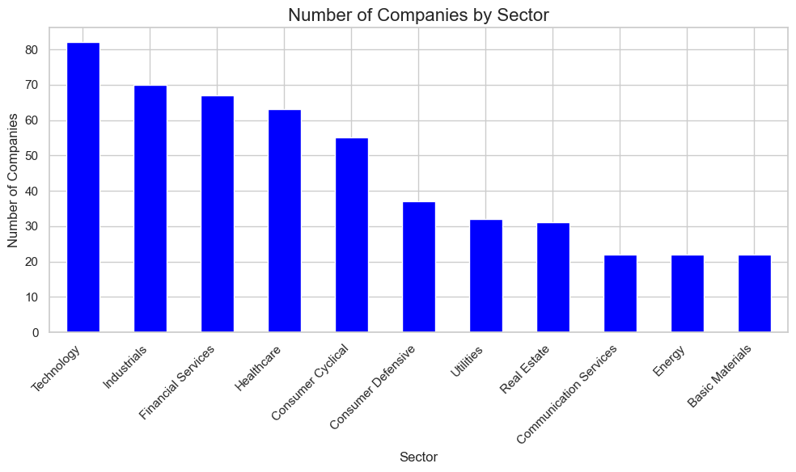

```python
plt.figure(figsize=(10, 6))
sector_counts = data['Sector'].value_counts()
sector_counts.plot(kind='bar', color='blue')
plt.title('Number of Companies by Sector', fontsize=16)
plt.ylabel('Number of Companies')
plt.xlabel('Sector')
plt.xticks(rotation=45, ha='right')
plt.tight_layout()
plt.show()
```

Now, let's compare `Market Cap` by `Sector`

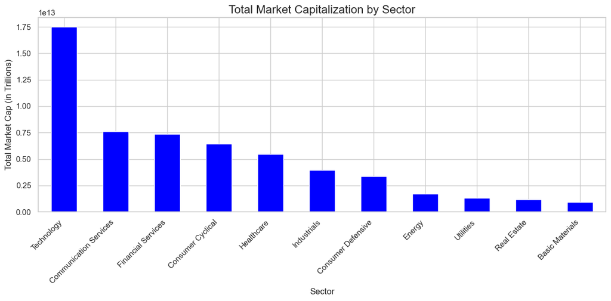

```python
plt.figure(figsize=(12, 6))
sector_marketcap = data.groupby('Sector')['Marketcap'].sum().sort_values(ascending=False)
sector_marketcap.plot(kind='bar', color='blue')
plt.title('Total Market Capitalization by Sector', fontsize=16)
plt.ylabel('Total Market Cap (in Trillions)')
plt.xlabel('Sector')
plt.xticks(rotation=45, ha='right')
plt.tight_layout()
plt.show()
```

Thirdly, we want to know the Distribution of Current Prices of stocks, which price is lower than $4000

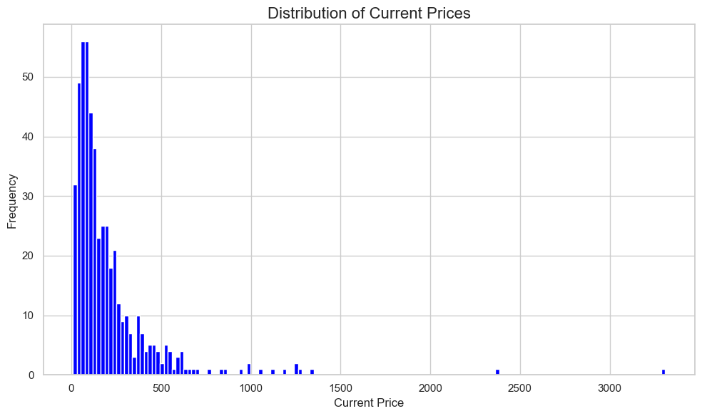

```python
plt.figure(figsize=(10, 6))
plt.hist(data[data["Currentprice"] < 4000]['Currentprice'], bins=150, color='blue')
plt.title('Distribution of Current Prices', fontsize=16)
plt.xlabel('Current Price')
plt.ylabel('Frequency')
plt.tight_layout()
plt.show()
```

Finally, Let's find the Correlation between `Revenue Growth` and `EBITDA`

[figure not shown]

```python
plt.figure(figsize=(10, 6))
sns.regplot(data=data[['Revenuegrowth', 'Ebitda']].corr(), x='Revenuegrowth', y='Ebitda', scatter_kws={'alpha':0.6}, line_kws={'color':'red'})
plt.title('Correlation between Revenue Growth and EBITDA', fontsize=16)
plt.xlabel('Revenue Growth')
plt.ylabel('EBITDA')
plt.tight_layout()
plt.show()
```

# Hypothesis Check

Hypothesis:

`Does Market Cap and EDITDA depends on the amount of Full-time employees`

Firstly, let's check the relation between market cap and employees

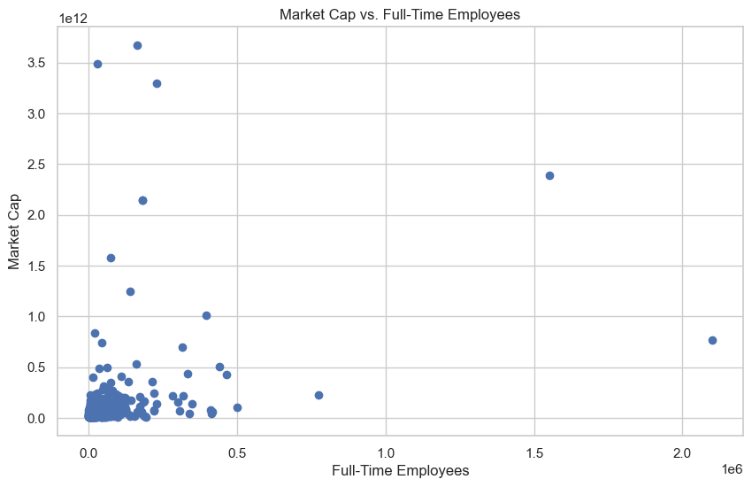

```python
plt.figure(figsize=(10, 6))
plt.scatter(data['Fulltimeemployees'], data['Marketcap'])
plt.xlabel('Full-Time Employees')
plt.ylabel('Market Cap')
plt.title('Market Cap vs. Full-Time Employees')
plt.show()
```

Now, let's do the same check for `EDITDA`

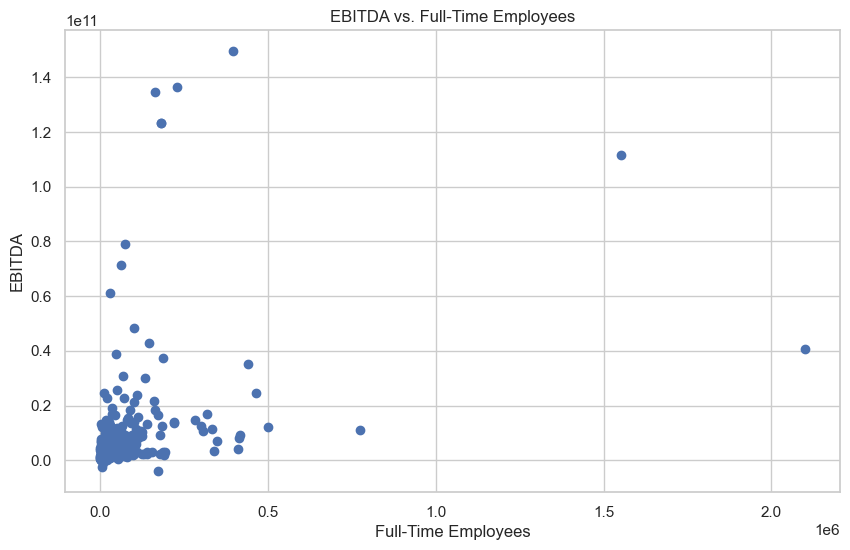

```python
plt.figure(figsize=(10, 6))
plt.scatter(data['Fulltimeemployees'], data['Ebitda'])
plt.xlabel('Full-Time Employees')
plt.ylabel('EBITDA')
plt.title('EBITDA vs. Full-Time Employees')
plt.show()
```

Almost the same looking chart, but now more points are not just "stuck" in the bottom position. Let's zoom in for better experience.

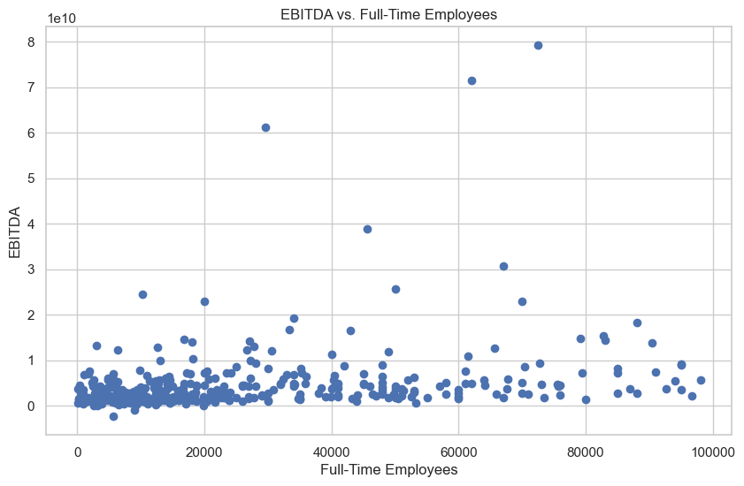

```python
plt.figure(figsize=(10, 6))
plt.scatter(data[data["Fulltimeemployees"] < 100_000]['Fulltimeemployees'], data[data["Fulltimeemployees"] < 100_000]['Ebitda'])
plt.xlabel('Full-Time Employees')
plt.ylabel('EBITDA')
plt.title('EBITDA vs. Full-Time Employees')
plt.show()
```

Based on that, we can definetely tell that most of the companies have around 20k `full-time employees` and they have almost the same `EBITDA`

Now, let's go on to the more complicated chart.

So, now it consists of:

```
+ Market Cap
+ Full-time Employees
+ EBITDA
```

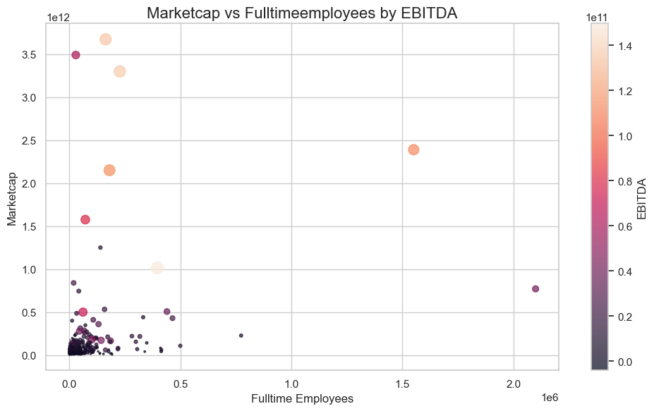

```python
plt.figure(figsize=(10, 6))
scatter = plt.scatter(
    data['Fulltimeemployees'],
    data['Marketcap'],
    c=data['Ebitda'],
    s=data['Ebitda'] / 1e9,
    alpha=0.7,
    edgecolor='face'
)

plt.colorbar(scatter, label='EBITDA')
plt.title('Marketcap vs Fulltimeemployees by EBITDA', fontsize=16)
plt.xlabel('Fulltime Employees')
plt.ylabel('Marketcap')
plt.tight_layout()
plt.show()
```

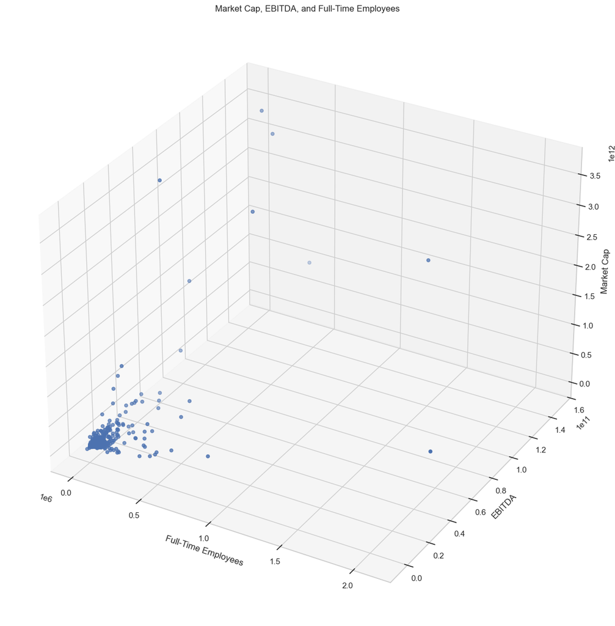

```python
fig = plt.figure(figsize=(20, 15))
ax = fig.add_subplot(111, projection='3d')
ax.scatter(data['Fulltimeemployees'], data['Ebitda'], data['Marketcap'])
ax.set_xlabel('Full-Time Employees')
ax.set_ylabel('EBITDA')
ax.set_zlabel('Market Cap')
plt.title('Market Cap, EBITDA, and Full-Time Employees')
plt.show()
```